# TestingNNpackages

Michal Segal Rozenhaimer

Monday, June 29, 2015

## Testing Kohonen package for unsupervised SOM

### SOM function

```r
## to find files under a certain package use:
## dir(system.file(package = "kohonen"), recursive = TRUE)
## to find where a library dataset exist use:
## system.file("rda", "wines.rda", package = "kohonen")

## Example for SOM of wines data

library(kohonen)
## data(wines)
## wines<-load("C:/Users/msegalro.NDC/Documents/R/win-library/3.1/kohonen/data/wines.rda")
data(wines)
set.seed(7)

## parse data - training
training <-sample(nrow(wines), 120)
Xtraining<-scale(wines[training, ])

## parse data - test
Xtest <-scale(wines[-training, ],
              center = attr(Xtraining, "scaled:center"),
              scale  = attr(Xtraining, "scaled:scale"))

## perform SOM
som.wines <-som(Xtraining, grid = somgrid(5, 5, "hexagonal"))

## predict
som.prediction <-predict(som.wines,
newdata = Xtest, trainX = Xtraining,
trainY = factor(wine.classes[training]))

## show result table
table(wine.classes[-training],
som.prediction$prediction)
```

```
##
##      1  2  3
##   1 18  0  0
##   2  1 19  4
##   3  0  0 15
```

## Now let’s see some plotting options

### “changes”

shows the mean distance to the closest codebook vector (neuron) during training.

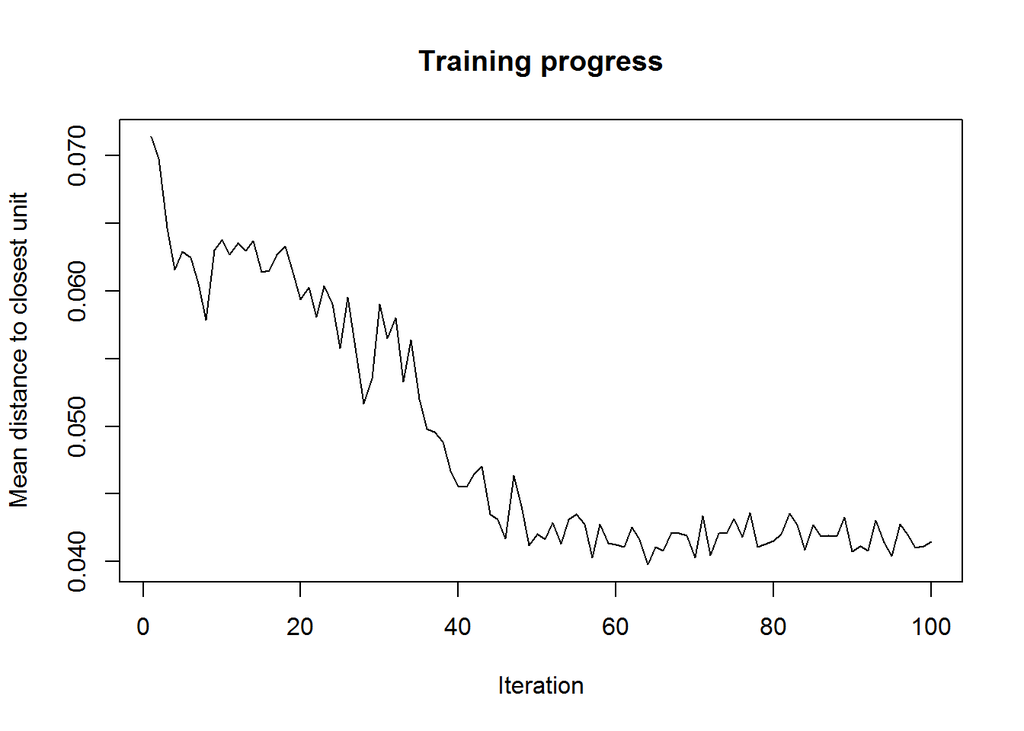

### “codes”

shows the codebook vector (reference vectors/neurons).

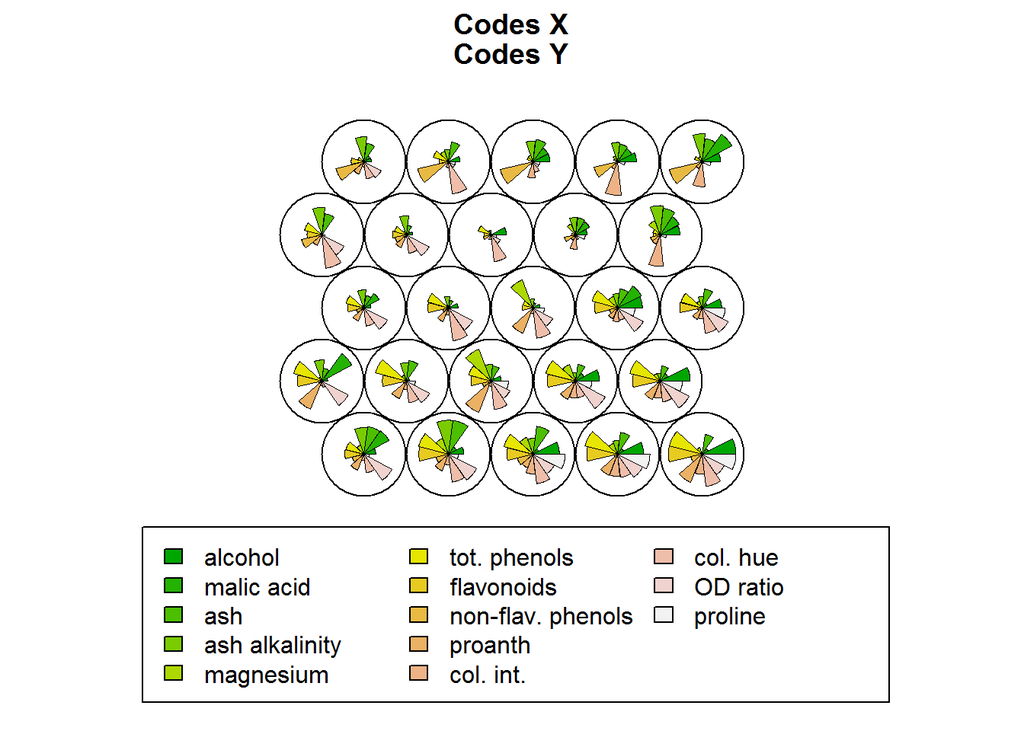

### “counts”

shows the number of objects mapped to the individual units. Empty units are depicted in gray.

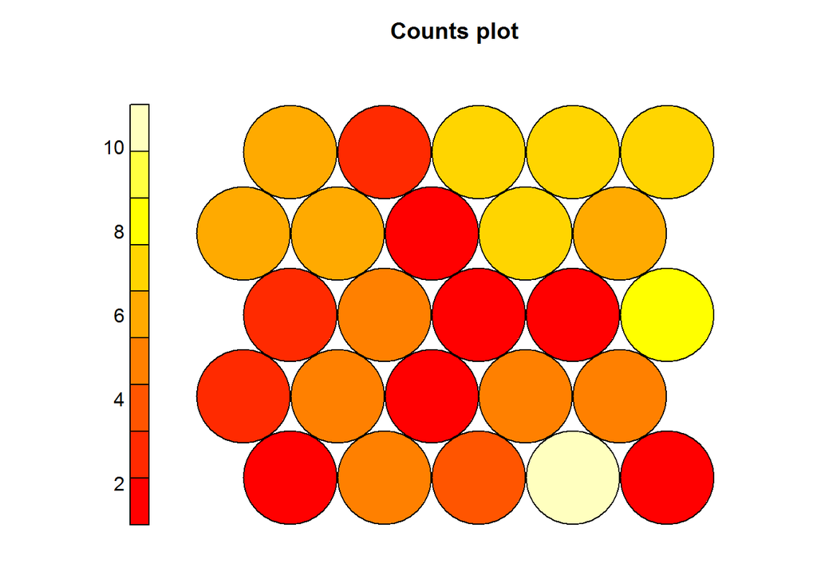

test counts with a different color scheme

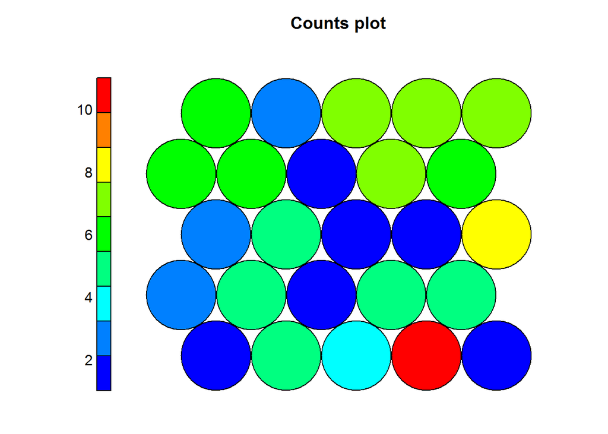

### “quality”

shows the mean distance of objects mapped to a unit to the codebook vector of that unit. The smaller the distances, the better the objects are represented by the codebook vectors.

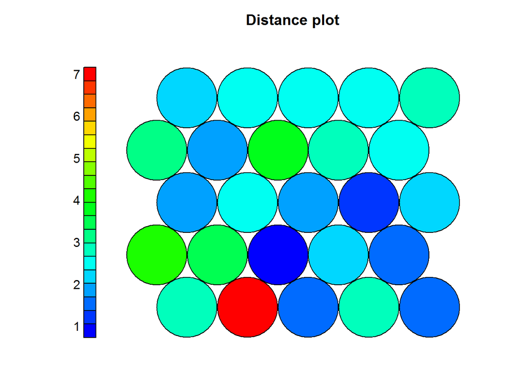

### “mapping”

shows where objects are mapped. It needs the “classif” argument, and a “labels” or “pchs” argument.

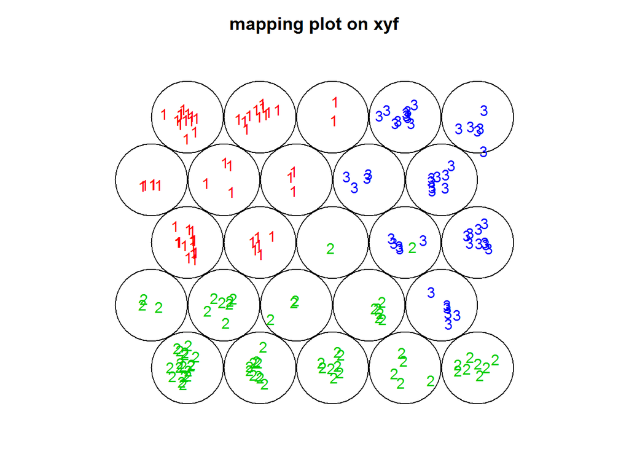

```r
## generate supervised kohonen map on wines data

kohmap <-xyf(scale(wines),
classvec2classmat(wine.classes),
grid = somgrid(5, 5, "hexagonal"), rlen=100)

## classvec2classmat converts a vector of classes (e.g. [11222333111])
## to a matrix representation of the classes (e.g. [1 0 0; 1 0 0; 0 1 0;...])

plot(kohmap,
type="mapping",
labels = wine.classes,
col = wine.classes+1,
main = "mapping plot on xyf")
```

another mapping plot with color scheme according to their predicted class labels: now add background color to each class

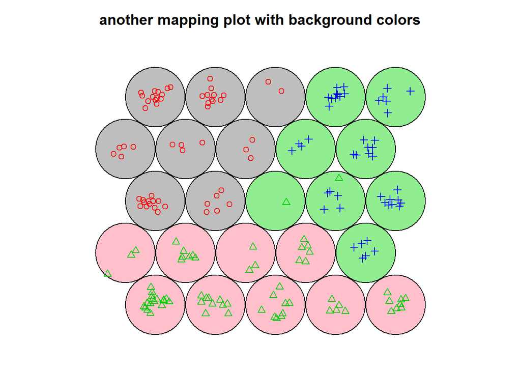

```r
## add background colors to units according to their predicted class labels

xyfpredictions <-classmat2classvec(predict(kohmap)$unit.predictions)
bgcols <-c("gray", "pink", "lightgreen")

plot(kohmap,
type="mapping",
col = wine.classes+1,
pchs = wine.classes,
bgcol = bgcols[as.integer(xyfpredictions)],
main = "another mapping plot with background colors")
```

### “property (component plane type plot)”

Using this method allows to understand how the different variables that comprise the input vectors are organized in the SOM output space.

plot based on 5x5 grid

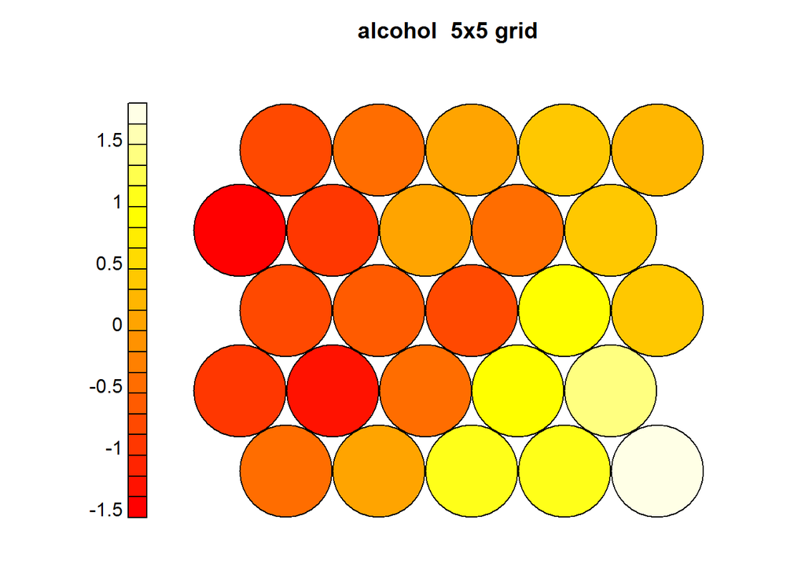

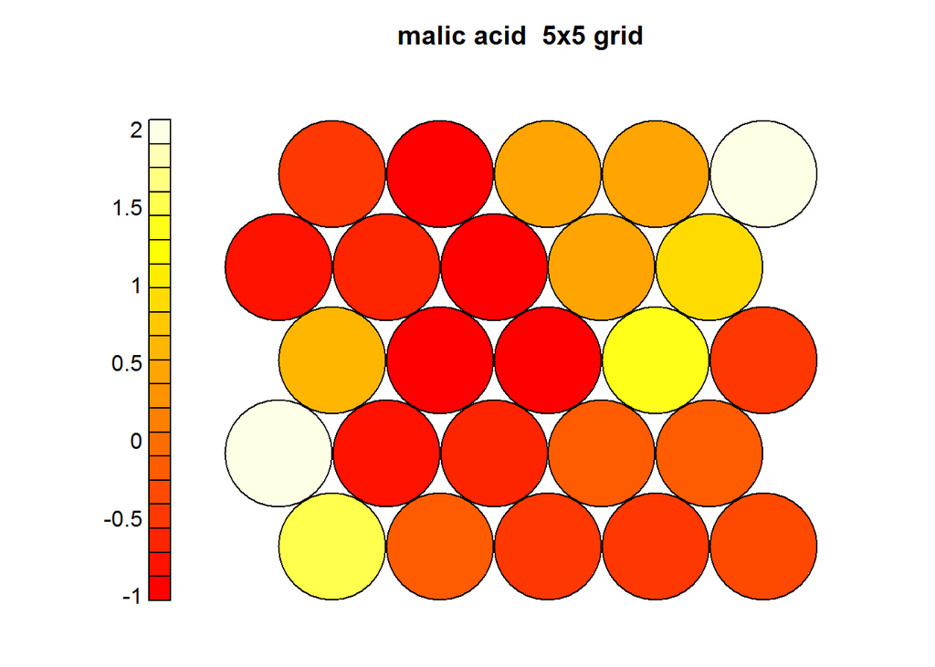

### U-matrix plot (Another way to show clustering information, i.e. dist.neighbours)

this shows sum of distances to all immidiate neighbours. units near a class boundary can be expected to have higher average distances to their neighbours

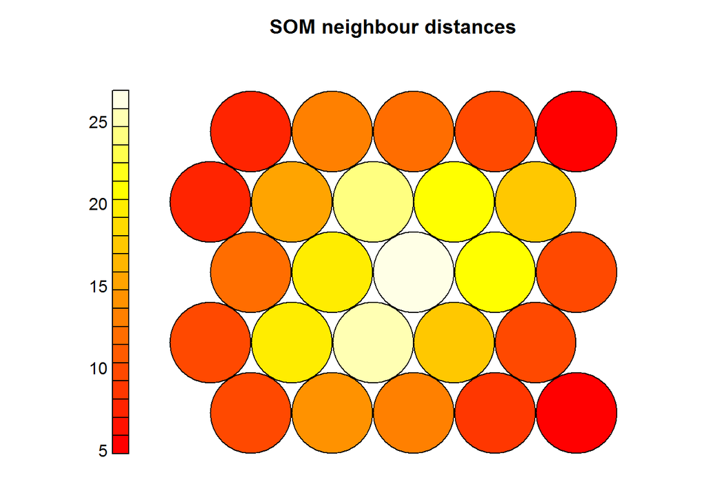

### use hierarchical clustering to cluster the codebook vectors (neurons)

solid black lines represent cluster boundaries

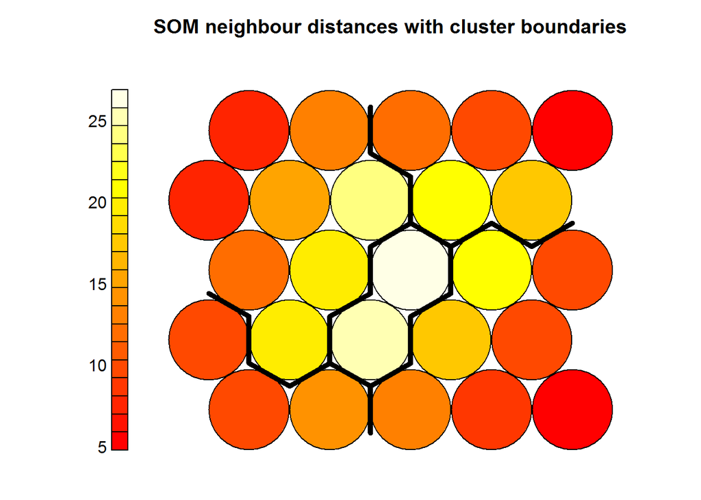

### example for the nir dataset

nir : Near-infrared data with temperature effects Description: A data object containing near-infrared spectra of ternary mixtures of ethanol, water and iso-propanol, measured at five different temperatures (30, 40, …, 70 degrees Centigrade). References : F. Wulfert , W.Th. Kok, A.K. Smilde: Anal. Chem. 1998, 1761-1767

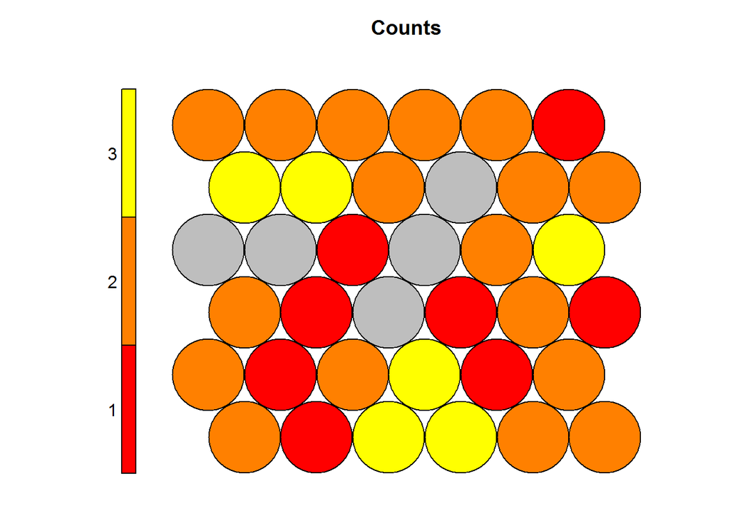

```r
data(nir)
set.seed(3)

## nir data contains 95 samples
## 200 spectral bands for each sample

nirnet <-xyf(data = nir$spectra[nir$training,],
Y = nir$composition[nir$training,],
xweight=.75,
grid = somgrid(6, 6, "hexagonal"), rlen=500)


plot(nirnet, "counts", main="Counts")
```

```r
## this is the prediction of all components
## this gives the major component (levels); not conc
## allcomp.xyf <-predict(nirnet)$prediction
```

### predict water content

water content is color-coded; temperature is circle size

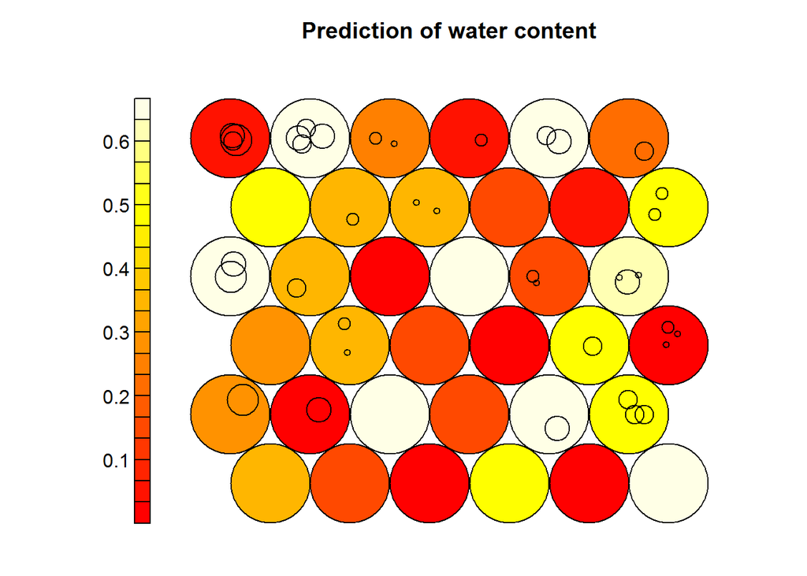

```r
## Focus on compound 2 (water):

##dev.new(width = 14)
##par(mfrow = c(1,2))
##data(nir)
set.seed(13)

nirnet2 <-xyf(data = nir$spectra[nir$training,],
Y = nir$composition[nir$training, 2],
grid = somgrid(6, 6, "hexagonal"), rlen=500)

## this is the prediction of water content
water.xyf <-predict(nirnet2)$prediction

plot(nirnet2, "property", property = water.xyf,
main="Prediction of water content")

## Plot temperatures as circles
symbols(nirnet2$grid$pts[nirnet2$unit.classif,] + matrix(rnorm(sum(nir$training)*2, sd=.1), ncol=2),
circles = (nir$temperature[nir$training] -20)/250, inches = FALSE, add = TRUE)
```

```r
## length(nirnet$unit.classif) = length of predicted samples
## each value in this vector gives the neuron number for the predicted sample
## e.g. first number in vector is 2,i.e. the first predicted spectrum belongs to neuron 2
## need to check what is unit.classif
```

### Model temperatures

open black circles are scaled according to water content

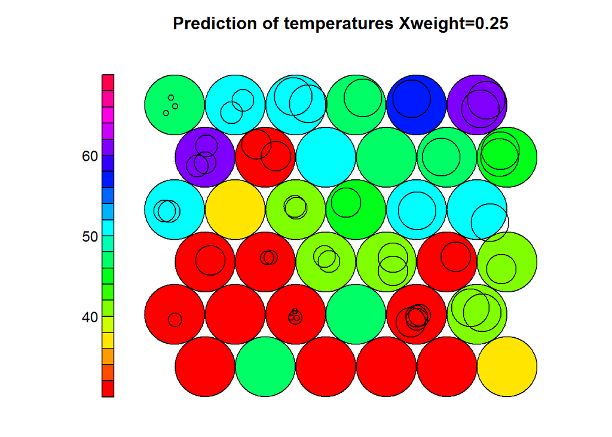

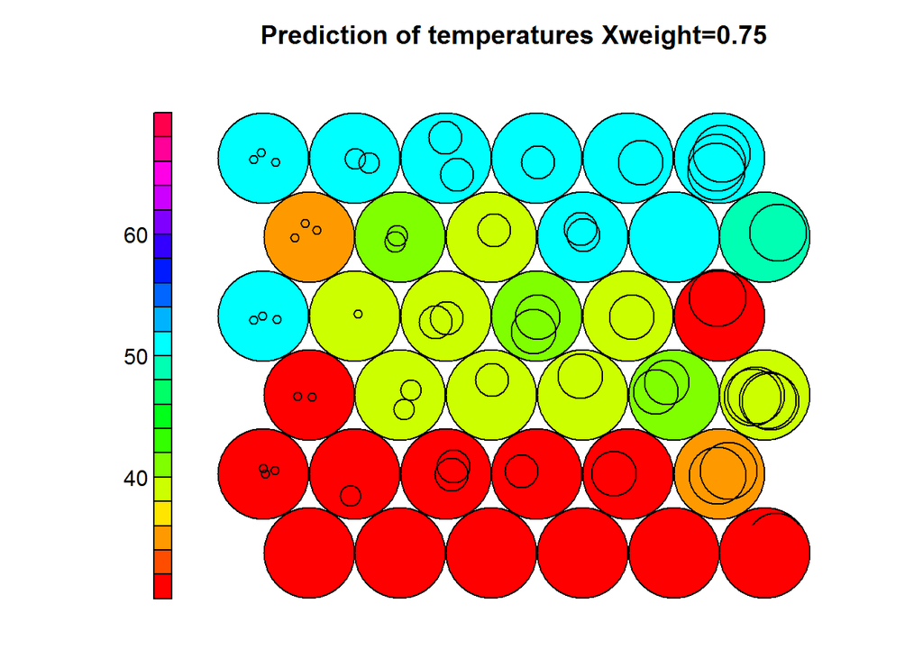